# Midterm

Jeff Gould

3/14/2021

# Analysis

## a)

$f(w_i) = \frac{w_i}{\theta^2} \exp(-\frac{w_i^2}{2 \theta^2})$

$$\begin{align*}
\begin{split}
\mathcal{L} &= \prod \frac{w_i}{\theta^2} \exp(-\frac{w_i^2}{2 \theta^2}) \\
&= (\frac{1}{\theta^2})^n \exp(-\frac{\sum w_i^2}{2 \theta^2})\prod w_i \\
&\propto (\theta^2)^{-n} \exp(-\frac{\sum w_i^2}{2 \theta^2})
\end{split}
\end{align*}$$

Which is the kernel for an Inverse Gamma distribution

So choose a non-informative IG prior: $\pi(\theta^2) \propto (\theta^2)^{-1}$

$$\begin{align*}
\begin{split}
P(\theta | W) &\propto (\theta^2)^{-1}(\theta^2)^{-n} \exp(-\frac{\sum w_i^2}{2 \theta^2}) \\
&= (\theta^2)^{-n-1}\exp\left(-\frac{\sum w_i^2}{2 \theta^2} \right)
\end{split}
\end{align*}$$

The kernel for an inverse-gamma distribution with parameters $\alpha=n$ and $\beta = \frac{\sum w_i^2}{2}$

$$\theta^2 \sim IG(n, \frac{\sum w_i^2}{2})$$

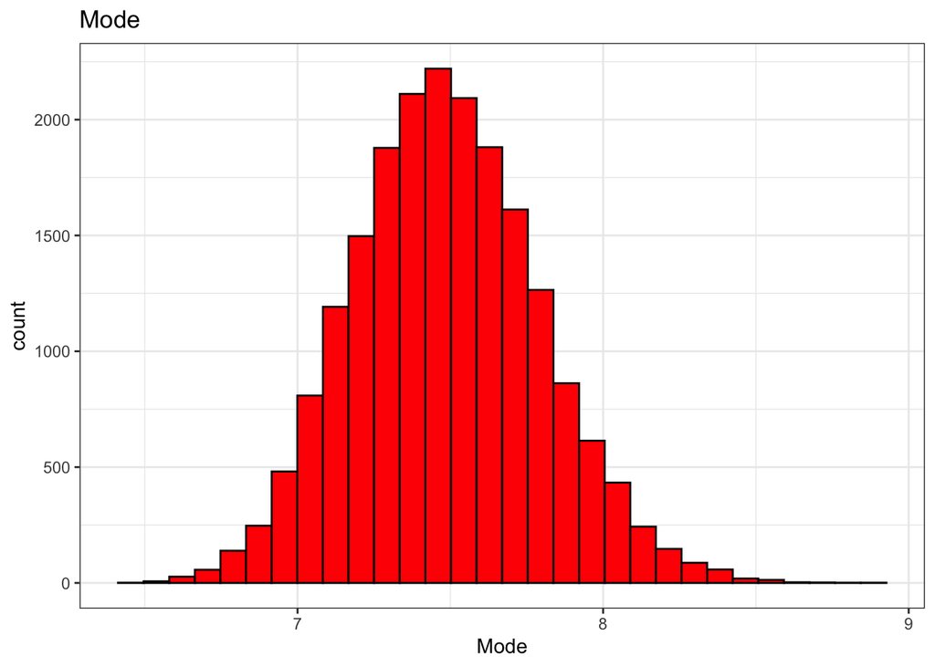

```r
wind <- read.delim("wind.txt", header = F)

alpha <- nrow(wind)
beta <- sum(wind^2) / 2


set.seed(6302)
theta <- MCMCpack::rinvgamma(n = 20000, shape = alpha, scale = beta)


theta.df <- data.frame(Theta2 = theta) %>%
  dplyr::mutate(Mode = sqrt(Theta2),
                Median = Mode*sqrt(2 * log(2)),
                Mean = Mode * sqrt(pi / 2))


ggplot(theta.df, aes(x = Mode)) +
  geom_histogram(col = "black", fill = "red") +
  theme_bw() +
  labs(title = "Mode")
```

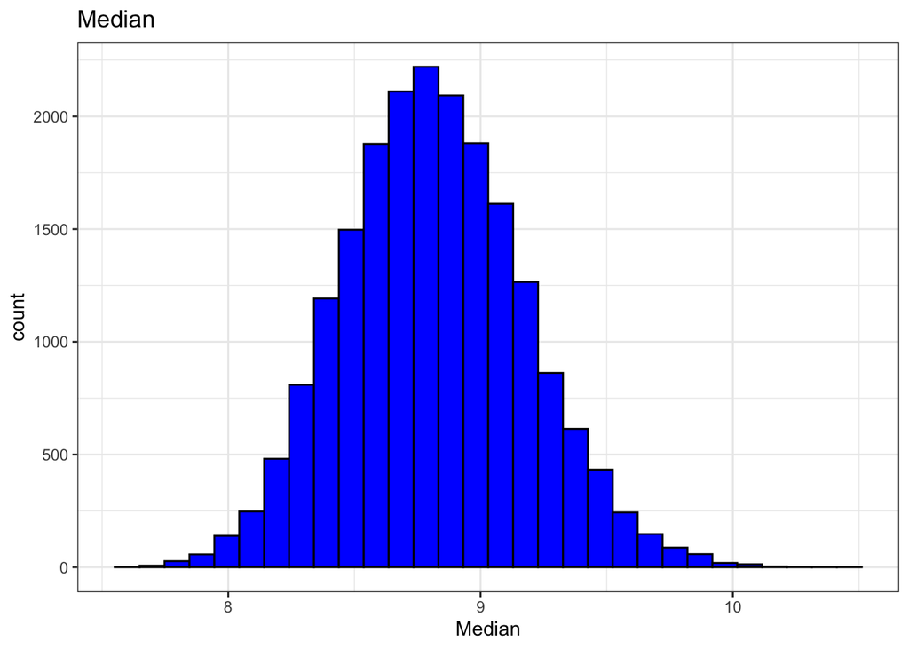

```r
ggplot(theta.df, aes(x = Median)) +
  geom_histogram(col = "black", fill = "blue") +
  theme_bw() +
  labs(title = "Median")
```

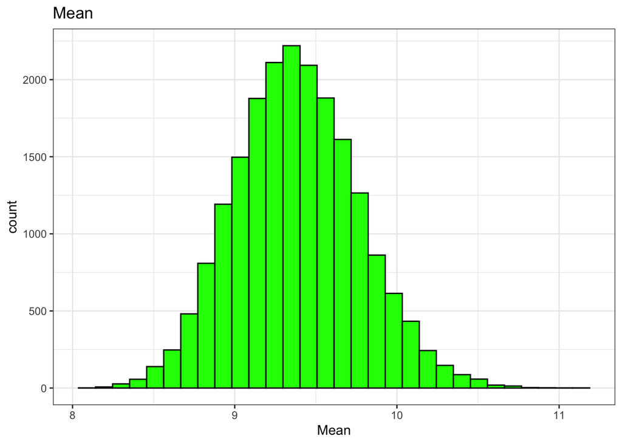

```r
ggplot(theta.df, aes(x = Mean)) +
  geom_histogram(col = "black", fill = "green") +
  theme_bw() +
  labs(title = "Mean")
```

```r
rbMat      <- apply(theta.df[,2:4], 2, quantile, probs = c(0.5, 0.025, 0.975))
```

## b)

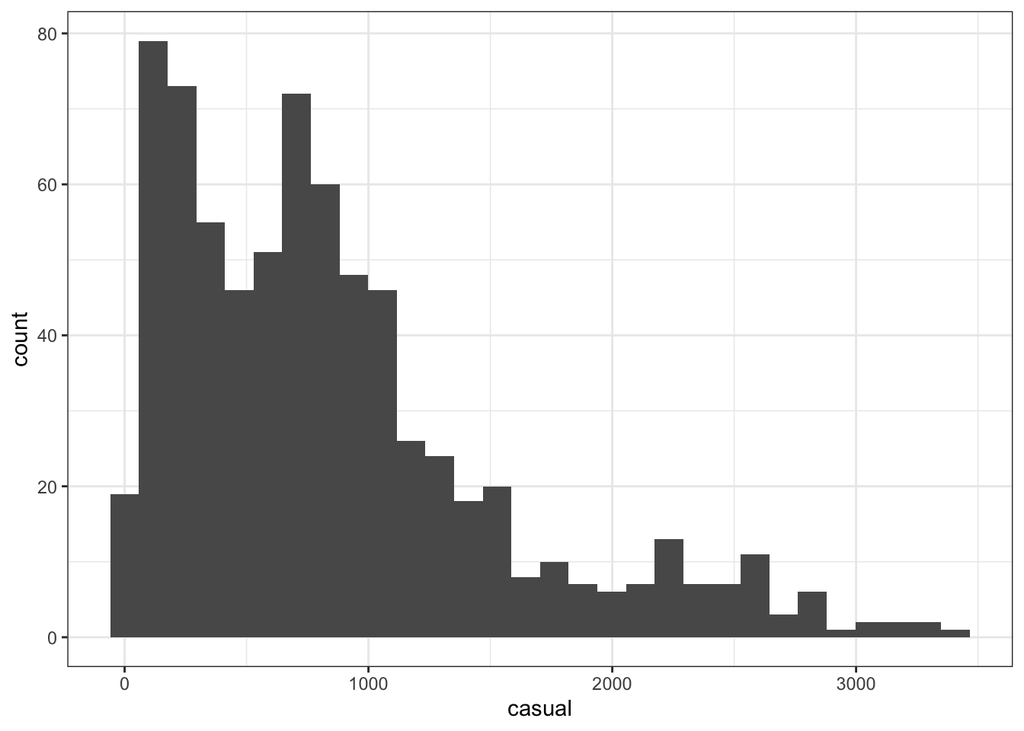

```r
bikeShare <- read.delim("day.txt", sep = " ")

ggplot(bikeShare, aes(x = casual)) +
  geom_histogram() +
  theme_bw()
```

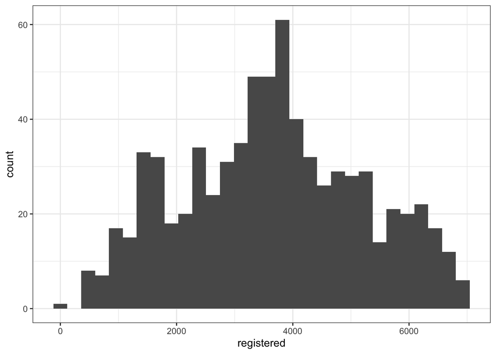

```r
ggplot(bikeShare, aes(x = registered)) +
  geom_histogram() +
  theme_bw()
```

It looks like the number of registered bikers in a day is relatively normally distributed. However, the number of casual bikers in a day is not normally distributed, and has a right-tail. Therefore we will log-transform the number of casual bikers

Registered Biker model:

```r
B     <- 20000
n     <- nrow(bikeShare)
X     <- model.matrix(registered ~ yr + holiday + workingday+ temp + atemp + hum + windspeed, data = bikeShare)
Y     <- bikeShare$registered
K     <- ncol(X)

bhat    <- c(solve(t(X)%*%X)%*%(t(X)%*%Y))
SSY <- t(Y - X%*%bhat)%*%(Y - X%*%bhat)
XtXi    <- solve(t(X)%*%X)
rbeta   <- matrix(0, nrow = B, ncol = K)

set.seed(726)
rsig    <- rinvgamma(B, (n-K)/2, (1/2)*SSY)
for(i in 1:B){
  CovX      <- rsig[i]*XtXi
  rbeta[i,] <- c(rmvnorm(1, mean = bhat, sigma = CovX))
}

rbMat      <- apply(rbeta, 2, quantile, probs = c(0.5, 0.025, 0.975))
postp    <- apply(rbeta > 0, 2, mean)
outMat   <- cbind(t(rbMat), postp)
rownames(outMat) <- colnames(X)
colnames(outMat) <- c(rownames(rbMat), 'P(b > 0)')
round(outMat,4)
```

```
##                    50%       2.5%      97.5% P(b > 0)
## (Intercept)  1492.2842  1068.4875  1909.3768   1.0000
## yr           1736.4844  1618.6585  1855.6594   1.0000
## holiday      -277.4642  -644.3167    87.0738   0.0679
## workingday    917.3964   785.6478  1048.8944   1.0000
## temp          510.8692 -2049.0673  3038.0597   0.6562
## atemp        4151.7529  1310.2404  7040.4651   0.9978
## hum         -1535.4455 -1976.5875 -1100.1794   0.0000
## windspeed   -3049.2338 -3863.0461 -2259.5336   0.0000
```

Building an initial model on all the possible covariates, we see that temperature and holiday are not statistically significant predictors. Let’s now remove them and build a new model

```r
B     <- 20000
n     <- nrow(bikeShare)
X     <- model.matrix(registered ~ yr  + workingday + atemp + hum + windspeed, data = bikeShare)
Y     <- bikeShare$registered
K     <- ncol(X)

bhat    <- c(solve(t(X)%*%X)%*%(t(X)%*%Y))
SSY <- t(Y - X%*%bhat)%*%(Y - X%*%bhat)
XtXi    <- solve(t(X)%*%X)
rbeta   <- matrix(0, nrow = B, ncol = K)

set.seed(726)
rsig    <- rinvgamma(B, (n-K)/2, (1/2)*SSY)
for(i in 1:B){
  CovX      <- rsig[i]*XtXi
  rbeta[i,] <- c(rmvnorm(1, mean = bhat, sigma = CovX))
}

rbMat      <- apply(rbeta, 2, quantile, probs = c(0.5, 0.025, 0.975))
postp    <- apply(rbeta > 0, 2, mean)
outMat   <- cbind(t(rbMat), postp)
rownames(outMat) <- colnames(X)
colnames(outMat) <- c(rownames(rbMat), 'P(b > 0)')
round(outMat,4)
```

```
##                    50%       2.5%     97.5% P(b > 0)
## (Intercept)  1438.6355  1037.3529  1848.109        1
## yr           1736.0399  1616.8166  1854.465        1
## workingday    942.2605   814.0901  1069.614        1
## atemp        4734.7868  4365.1382  5105.350        1
## hum         -1539.0372 -1970.6135 -1101.620        0
## windspeed   -3011.4854 -3810.1584 -2218.712        0
```

Now we have a model with all statistically significant variables

And predict the number of riders on February 29, 2012:

```r
theta <- matrix(c(1, 1, 1, 0.34847, 0.804783, 0.179117), ncol = 1)
predicted <- data.frame(Registered = rbeta %*% theta)
```

Now Casual riders:

```r
B     <- 20000
n     <- nrow(bikeShare)
bikeShare$logCasual <- log(bikeShare$casual)

X     <- model.matrix(logCasual ~ yr + holiday + workingday+ temp + atemp + hum + windspeed, data = bikeShare)
Y     <- bikeShare$logCasual
K     <- ncol(X)

bhat    <- c(solve(t(X)%*%X)%*%(t(X)%*%Y))
SSY <- t(Y - X%*%bhat)%*%(Y - X%*%bhat)
XtXi    <- solve(t(X)%*%X)
rbeta   <- matrix(0, nrow = B, ncol = K)

set.seed(97)
rsig    <- rinvgamma(B, (n-K)/2, (1/2)*SSY)
for(i in 1:B){
  CovX      <- rsig[i]*XtXi
  rbeta[i,] <- c(rmvnorm(1, mean = bhat, sigma = CovX))
}

rbMat      <- apply(rbeta, 2, quantile, probs = c(0.5, 0.025, 0.975))
postp    <- apply(rbeta > 0, 2, mean)
outMat   <- cbind(t(rbMat), postp)
rownames(outMat) <- colnames(X)
colnames(outMat) <- c(rownames(rbMat), 'P(b > 0)')
round(outMat,4)
```

```
##                 50%    2.5%   97.5% P(b > 0)
## (Intercept)  5.9222  5.6340  6.2080   1.0000
## yr           0.3747  0.2922  0.4568   1.0000
## holiday     -0.2440 -0.4962  0.0060   0.0281
## workingday  -0.8972 -0.9878 -0.8077   0.0000
## temp         0.3857 -1.3762  2.1307   0.6671
## atemp        3.8582  1.8860  5.8469   1.0000
## hum         -1.3196 -1.6160 -1.0235   0.0000
## windspeed   -1.7366 -2.3008 -1.1842   0.0000
```

Again, temperature and holiday are not statistically significant predictors. Remove them from model and build new one

```r
B     <- 20000
n     <- nrow(bikeShare)
bikeShare$logCasual <- log(bikeShare$casual)

X     <- model.matrix(logCasual ~ yr + workingday + atemp + hum + windspeed, data = bikeShare)
Y     <- bikeShare$logCasual
K     <- ncol(X)

bhat    <- c(solve(t(X)%*%X)%*%(t(X)%*%Y))
SSY <- t(Y - X%*%bhat)%*%(Y - X%*%bhat)
XtXi    <- solve(t(X)%*%X)
rbeta   <- matrix(0, nrow = B, ncol = K)

set.seed(97)
rsig    <- rinvgamma(B, (n-K)/2, (1/2)*SSY)
for(i in 1:B){
  CovX      <- rsig[i]*XtXi
  rbeta[i,] <- c(rmvnorm(1, mean = bhat, sigma = CovX))
}

rbMat      <- apply(rbeta, 2, quantile, probs = c(0.5, 0.025, 0.975))
postp    <- apply(rbeta > 0, 2, mean)
outMat   <- cbind(t(rbMat), postp)
rownames(outMat) <- colnames(X)
colnames(outMat) <- c(rownames(rbMat), 'P(b > 0)')
round(outMat,4)
```

```
##                 50%    2.5%   97.5% P(b > 0)
## (Intercept)  5.8795  5.6049  6.1553        1
## yr           0.3738  0.2906  0.4562        1
## workingday  -0.8746 -0.9623 -0.7877        0
## atemp        4.2966  4.0403  4.5484        1
## hum         -1.3215 -1.6200 -1.0268        0
## windspeed   -1.7144 -2.2724 -1.1637        0
```

```r
theta <- matrix(c(1, 1, 1, 0.34847, 0.804783, 0.179117), ncol = 1)
predicted$Casual <- exp(rbeta %*% theta)

predRiders  <- apply(predicted, 2, quantile, probs = c(0.5, 0.025, 0.975))
meanPred    <- apply(predicted , 2, mean)
outMat   <- cbind(t(predRiders), meanPred)
outMat
```

```
##                  50%      2.5%     97.5%  meanPred
## Registered 3989.5648 3852.3489 4126.5145 3989.4965
## Casual      245.7582  223.4443  270.3632  246.0946
```